```python
import numpy as np
```

# Combining array

Arrays can be combined in various ways. This process in NumPy is referred to as `stacking`. Stacking can take various forms, including `horizontal`, `vertical`, and `depth-wise` stacking. To demonstrate this, we will use the following two arrays

- `stack` means 1 ke uppar 1 rakhna ya saath rakhna

# Stacking

Join a sequence of arrays along a new axix.

```python
# create two arrays

a = np.arange(9).reshape(3,3)
b = np.arange(9,18).reshape(3,3)

print(a)
print("=============")
print(b)
```

```
[[0 1 2]
 [3 4 5]
 [6 7 8]]
=============
[[ 9 10 11]
 [12 13 14]
 [15 16 17]]
```

```python
# Simply stacking array a and b:
# stack ka matlab ye hai ke 1 array rakhi hui hai, uske peechay ya uppar doosri array ko rakhdena
# samjahna ye hai ke jab ye stack hongi t 3d bnjayegi, How?
np.stack((a,b))
```

```
array([[[ 0,  1,  2],
        [ 3,  4,  5],
        [ 6,  7,  8]],

       [[ 9, 10, 11],
        [12, 13, 14],
        [15, 16, 17]]])
```

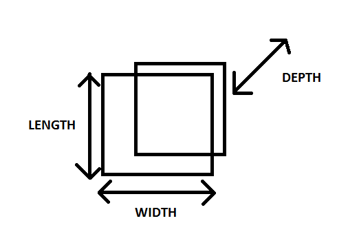

# Horizontal Stacking

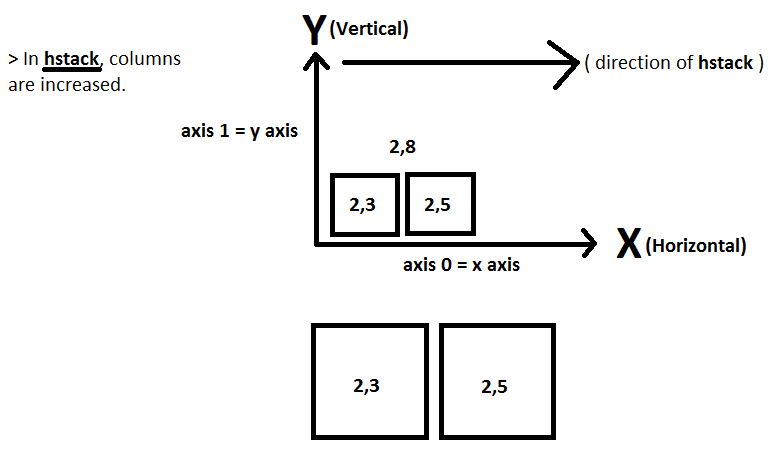

Combines two arrays in a manner where the columns of the second array are placed to the right of those in the first array. The function actually stacks the two items provided in a two-element tuple. The result is a new array with data copied from the two that are specified:

```python
arr1 = np.arange(16).reshape(8,2)
arr1
```

```
array([[ 0,  1],
       [ 2,  3],
       [ 4,  5],
       [ 6,  7],
       [ 8,  9],
       [10, 11],
       [12, 13],
       [14, 15]])
```

```python
arr2 = np.arange(16,56).reshape(8,5)
arr2
```

```
array([[16, 17, 18, 19, 20],
       [21, 22, 23, 24, 25],
       [26, 27, 28, 29, 30],
       [31, 32, 33, 34, 35],
       [36, 37, 38, 39, 40],
       [41, 42, 43, 44, 45],
       [46, 47, 48, 49, 50],
       [51, 52, 53, 54, 55]])
```

```python
# dono haath phelana parenge

np.hstack((arr1,arr2))
```

```
array([[ 0,  1, 16, 17, 18, 19, 20],
       [ 2,  3, 21, 22, 23, 24, 25],
       [ 4,  5, 26, 27, 28, 29, 30],
       [ 6,  7, 31, 32, 33, 34, 35],
       [ 8,  9, 36, 37, 38, 39, 40],
       [10, 11, 41, 42, 43, 44, 45],
       [12, 13, 46, 47, 48, 49, 50],
       [14, 15, 51, 52, 53, 54, 55]])
```

```python
# axis 1 hamare pass y axis hota hai >>>> similar to hstack

np.concatenate((arr1,arr2), axis=1)
```

```
array([[ 0,  1, 16, 17, 18, 19, 20],
       [ 2,  3, 21, 22, 23, 24, 25],
       [ 4,  5, 26, 27, 28, 29, 30],
       [ 6,  7, 31, 32, 33, 34, 35],
       [ 8,  9, 36, 37, 38, 39, 40],
       [10, 11, 41, 42, 43, 44, 45],
       [12, 13, 46, 47, 48, 49, 50],
       [14, 15, 51, 52, 53, 54, 55]])
```

# Vertical Stacking

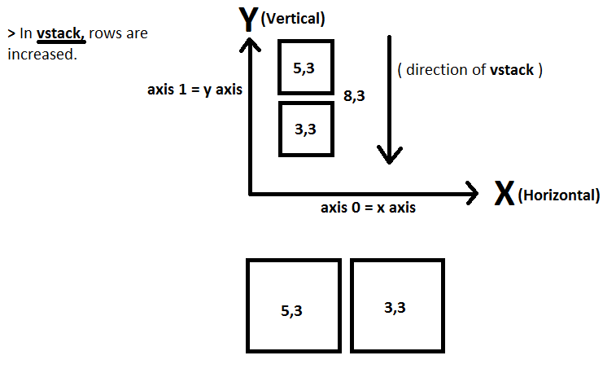

Vertical stacking returns a new array with the contents of the second array as appended rows of the first array.

```python
arr3 = np.arange(20).reshape(2,10)
arr3
```

```
array([[ 0,  1,  2,  3,  4,  5,  6,  7,  8,  9],
       [10, 11, 12, 13, 14, 15, 16, 17, 18, 19]])
```

```python
arr4 = np.arange(20,60).reshape(4,10)
arr4
```

```
array([[20, 21, 22, 23, 24, 25, 26, 27, 28, 29],
       [30, 31, 32, 33, 34, 35, 36, 37, 38, 39],
       [40, 41, 42, 43, 44, 45, 46, 47, 48, 49],
       [50, 51, 52, 53, 54, 55, 56, 57, 58, 59]])
```

```python
np.vstack((arr3,arr4))
```

```
array([[ 0,  1,  2,  3,  4,  5,  6,  7,  8,  9],
       [10, 11, 12, 13, 14, 15, 16, 17, 18, 19],
       [20, 21, 22, 23, 24, 25, 26, 27, 28, 29],
       [30, 31, 32, 33, 34, 35, 36, 37, 38, 39],
       [40, 41, 42, 43, 44, 45, 46, 47, 48, 49],
       [50, 51, 52, 53, 54, 55, 56, 57, 58, 59]])
```

```python
np.concatenate((arr3,arr4),axis=0)
```

```
array([[ 0,  1,  2,  3,  4,  5,  6,  7,  8,  9],
       [10, 11, 12, 13, 14, 15, 16, 17, 18, 19],
       [20, 21, 22, 23, 24, 25, 26, 27, 28, 29],
       [30, 31, 32, 33, 34, 35, 36, 37, 38, 39],
       [40, 41, 42, 43, 44, 45, 46, 47, 48, 49],
       [50, 51, 52, 53, 54, 55, 56, 57, 58, 59]])
```

# Columns Stacking

DYS

# Row Stacking

DYS

# Depth Stacking

takes a list of arrays and arranges them in order along an additional axis referred to as the depth:

- dstack stacks each independent column of a and b

```python
arr5 = np.arange(9).reshape(3,3)
arr5
```

```
array([[0, 1, 2],
       [3, 4, 5],
       [6, 7, 8]])
```

```python
arr6 = np.arange(9,18).reshape(3,3)
arr6
```

```
array([[ 9, 10, 11],
       [12, 13, 14],
       [15, 16, 17]])
```

```python
# jab mai ne kaha isko ke depth stack kardo arr5 or arr6 ko to depth stack bilkul wese hee hoga jese humne sirf khaali ..
# ..stack mai kia tha, matalab bilkul wese hee nhi hoga lekin banegi ismai 3d hee, jistarah stacking mai 3d ban rhi thi, 1 ke..
# ..peechay 1 chale gyi thi, dstack mai bhi 3d hee banegi qk depth wise ye 3rd dimension main array ko ye add karega, matrix..
# ko ye 3eesri dimension mai add karega LEFT, RIGHT, UP and DOWN add nhi karega balke ye backside pe add karega, jab ye ..
# ..backside pe add karega to cube ki tarah 3eesri dimension banna shuru hojayegi, lekin ye to stacking mai horha tha,..
#stacking mai wo poori image uthake uske peechay ese hee rakh deta tha, lekin jab depth stacking karenge to iska thora format..
# change hai
# ye input arrays ki thori si dimension bhi change karta hai, isne stack ki tarah add nhi kardya balke isne dimension bhi .
# .. change kardi, sab sai pehle ye baat ke both input arrays 3 by 3 shape ki hain to number of elements honge apke pass 18
# ab 18 ka 3d stack kia kia bansakta hai? >>> 3,2,3 =>18 OR >>> 2,3,3 =>18 OR >>> 3,3,2 =>18 to ye 3 possibility hain ye apni..
# marzi sai ab sawaal ye hai ke isne yahan kia hai?? to depth stacking mai 3d mai hee ans ayega

dstacked = np.dstack((arr5,arr6))
print(dstacked)
print(dstacked.shape)
```

```
[[[ 0  9]
  [ 1 10]
  [ 2 11]]

 [[ 3 12]
  [ 4 13]
  [ 5 14]]

 [[ 6 15]
  [ 7 16]
  [ 8 17]]]
(3, 3, 2)
```

# Splitting arrays

Arrays can also be split into multiple arrays along the `horizontal`, `vertical` and `depth` axis using the `np.hsplit()`, `np.vsplit()`, and `np.dsplit()` functions. We will only look at the np.hsplit() function as the other work similarly.

```python
# if I split into 2 equal parts it will reusult in an error bcoz 9 values can't be splitted into 2

x = np.arange(9.0)
print(x)
print("=============")
print(np.split(x, 3))
```

```
[0. 1. 2. 3. 4. 5. 6. 7. 8.]
=============
[array([0., 1., 2.]), array([3., 4., 5.]), array([6., 7., 8.])]
```

```python
a = np.arange(12).reshape(3,4)
a
```

```
array([[ 0,  1,  2,  3],
       [ 4,  5,  6,  7],
       [ 8,  9, 10, 11]])
```

```python
# horizontal split the 2d array into 4 array columns
# horizontal kaatne mai jawab columns mai arhe hain

print(np.hsplit(a,4))
print("========================")
print(np.hsplit(a,2))
```

```
[array([[0],
       [4],
       [8]]), array([[1],
       [5],
       [9]]), array([[ 2],
       [ 6],
       [10]]), array([[ 3],
       [ 7],
       [11]])]
========================
[array([[0, 1],
       [4, 5],
       [8, 9]]), array([[ 2,  3],
       [ 6,  7],
       [10, 11]])]
```

```python
print(a)
```

```
[[ 0  1  2  3]
 [ 4  5  6  7]
 [ 8  9 10 11]]
```

```python
# Split at columns 1 and 3

np.hsplit(a, [1,3])
```

```
[array([[0],
        [4],
        [8]]),
 array([[ 1,  2],
        [ 5,  6],
        [ 9, 10]]),
 array([[ 3],
        [ 7],
        [11]])]
```

# Useful numerical methods of NumPy arrays

```python
# demonstrate some of the properties of NumPy arrays
m = np.arange(10,19).reshape(3,3)
print(m)
print("{0} min of the entire matrix".format(m.min()))
print("{0} max of the entire matrix".format(m.max()))
print("{0} position of the min value".format(m.argmin()))     # index of minValue, yaani wo minValue kaha parhi hai, value nhi
print("{0} position of the max value".format(m.argmax()))     # index of maxValue
print("{0} mins down each column".format(m.min(axis=0)))      # to har col mai min value 10, 11, 12 hai
print("{0} mins across each row".format(m.min(axis=1)))       # min value of every row
print("{0} maxs down each column".format(m.max(axis=0)))
```

```
[[10 11 12]
 [13 14 15]
 [16 17 18]]
10 min of the entire matrix
18 max of the entire matrix
0 position of the min value
8 position of the max value
[10 11 12] mins down each column
[10 13 16] mins across each row
[16 17 18] maxs down each column
```

# Some statistical function

```python
my_array = np.arange(36).reshape(6,6)
my_array_array
```

[output not shown]

```python
print(f"The mean of the array is {my_array.mean()}")
print(f"The standar deviation of the array is {my_array.std()}")
print(f"The variation of the array is {my_array.var()}")
```

```
The mean of the array is 17.5
The standar deviation of the array is 10.388294694831615
The variation of the array is 107.91666666666667
```

```python
print(f"The sum of the array is {my_array.sum()}")
print(f"The product of the array is {my_array.prod()}")
```

```
The sum of the array is 630
The product of the array is 0
```

```python
print(f"The cumulative sum of the array is {my_array.cumsum()}")
print(f"The cumulative product of the array is {my_array.cumprod()}")
```

```
The cumulative sum of the array is [  0   1   3   6  10  15  21  28  36  45  55  66  78  91 105 120 136 153
 171 190 210 231 253 276 300 325 351 378 406 435 465 496 528 561 595 630]
The cumulative product of the array is [0 0 0 0 0 0 0 0 0 0 0 0 0 0 0 0 0 0 0 0 0 0 0 0 0 0 0 0 0 0 0 0 0 0 0 0]
```

# Applying logical operators on arrays

```python
# Logical ka ans hamare pass hamesha True ya False mai ata hai
a = np.arange(10)
a
```

```
array([0, 1, 2, 3, 4, 5, 6, 7, 8, 9])
```

```python
# .any() returns True if any if any of the values is less than 5

(a < 5).any()   # poori array mai agar 1 bhi less than 5 hooga to ye True return kardega
```

```
True
```

```python
# .all() return True if and only if all the values are less than 5
(a < 5).all()
```

```
False
```

# Boolean Indexing

```python
names = np.array(['Bob', 'Joe', 'Will', 'Bob', 'Will', 'Joe', 'Joe'])
names
```

```
array(['Bob', 'Joe', 'Will', 'Bob', 'Will', 'Joe', 'Joe'], dtype='<U4')
```

```python
# 1st row Bob ki hai, to har row ka 1 naam banadiya humne
data =np.array(np.random.randn(7, 4)*10,dtype=np.int)
data
```

```
array([[ -8,   8,   7,   2],
       [ 11, -17,   1, -10],
       [ 17,   0,  -4,   8],
       [  3,  -1,  -2,  -6],
       [-21,  -6,  11,  -2],
       [-15,  17, -13,   4],
       [  9, -11, -14, -16]])
```

Suppose each name corresponds to a row in the data array and we wanted to select all the rows with corresponding name 'Bob'.

Like arithmetic operations, comparisons (such as ==) with arrays are also vectorized.

Thus, comparing names with the string 'Bob' yields a boolean array:

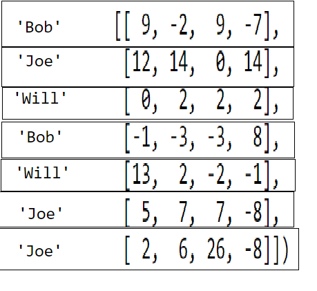

First consdier this, if we wnat to select (fancy selection) different rows from array we can pass a list of row indices.

But a big but, if we want to select different rows based on some criteria like here we want all rows corresponding to name 'Bob'

we will do booean indexing

```python
# slicing mai start sai end tak mai mangliya karta tha lekin fancy indexing mai mere farmayishen shuru hogyin hain, yahan..
# ..main keh rha hun ke 3eesri dedo 5wee dedo or akhri dedo, to humne dekha hai ke selection contiguous form mai hota hai..
# ..yani 1 saath 1 honi chahiyen, ye jo idhar udhar sai uthakar dedo ye kese karenge, ye idhar udhar sai uthan isko kehte..
# ..hain fancy indexing, to fancy indexing mai mujhe jo cheezen chahiyen hoti hain unki mai poori list banakar deta hun

data[[0,3,5]]
```

```
array([[ -8,   8,   7,   2],
       [  3,  -1,  -2,  -6],
       [-15,  17, -13,   4]])
```

```python
#boolean indexing now
# to huemin ab boolean indexing karni hai fancy indexing ki madad sai
# poori names array ko compare karega Bob sai, ab jawab main hamare pass boolean result ayega, jahan par Bob hoga wahn True..
# ..ayega jahan jahan Bob nhi hoga wahan False ayega

# ab yehi jo result hai mai isko fancy indexing mai index number dene ki bajaye main yehi result True False wala yahan pass ..
# ..kardun

names == 'Bob' # vectorize comparision,will return true where name is bob in names array.
```

```
array([ True, False, False,  True, False, False, False])
```

this result can be passed in to data array to select True rows based on True and False (boolean)

```python
# to yahan True wali rows ajayengi or False wali nhi ayengi
# isne mujhe 2 results diye hain joke True aye hain

data[[ True, False, False,  True, False, False, False]]   # this way
```

```
array([[-8,  8,  7,  2],
       [ 3, -1, -2, -6]])
```

```python
# a better way is:
# ab maine yahan par eik boolean expression pass kardi hai
data[names=='Bob'] # definitely inside data brackets boolean array will be generated by names=='Bob'
```

```
array([[-8,  8,  7,  2],
       [ 3, -1, -2, -6]])
```

```python
# wo le ao jahan Bob nhi hain yaani mujhe bar bar True False nhi likhna par rha expression likhne sai mera kaam asaan hogya
# hum ye usko mask banakar derhe hain joke True False ki soorat mai convert horha hai

data[names!='Bob']
```

```
array([[ 11, -17,   1, -10],
       [ 17,   0,  -4,   8],
       [-21,  -6,  11,  -2],
       [-15,  17, -13,   4],
       [  9, -11, -14, -16]])
```

Selecting two of the three names to combine multiple boolean conditions, use boolean arithmetic operators like & (and) and | (or)

```python
# wo rows le ao jin ka naam Bob ho ya Will ho
# ab is mask ka ans True ya False mai hee ayega
mask = (names == 'Bob') | (names == 'Will')

# this is multiple names condition generating a sort of mask to provide to data array
##### The Python keywords (and) and (or) do not work with bolean arrays.#############
###### Use &(and) and |(or) instead.. #########3
```

```python
data[mask]
```

```
array([[ -8,   8,   7,   2],
       [ 17,   0,  -4,   8],
       [  3,  -1,  -2,  -6],
       [-21,  -6,  11,  -2]])
```

```python
data[data < 0] = 0   # another way! It replaces all the values on True indexing with 0
```

```python
# har 0 sai choti value 0 bangyi
data
```

```
array([[ 0,  8,  7,  2],
       [11,  0,  1,  0],
       [17,  0,  0,  8],
       [ 3,  0,  0,  0],
       [ 0,  0, 11,  0],
       [ 0, 17,  0,  4],
       [ 9,  0,  0,  0]])
```

#### Fancy Indexing with columns

```python
# column number 0 dedo or 3 dedo

data[:, [0,3]]
```

```
array([[ 0,  2],
       [11,  0],
       [17,  8],
       [ 3,  0],
       [ 0,  0],
       [ 0,  4],
       [ 9,  0]])
```

# Transposing Arrays and Swapping Axis

```python
# tranpose karne ka matlab hota hai ke array ki direction ko change karna, yani jo row hai wo col banjayege or col row banjayega
print(data)

data.T   # T >>> property
```

```
[[ 0  8  7  2]
 [11  0  1  0]
 [17  0  0  8]
 [ 3  0  0  0]
 [ 0  0 11  0]
 [ 0 17  0  4]
 [ 9  0  0  0]]
```

```
array([[ 0, 11, 17,  3,  0,  0,  9],
       [ 8,  0,  0,  0,  0, 17,  0],
       [ 7,  1,  0,  0, 11,  0,  0],
       [ 2,  0,  8,  0,  0,  4,  0]])
```

```python
np.transpose(data)    # now it is function for transposing an array
```

```
array([[ 0, 11, 17,  3,  0,  0,  9],
       [ 8,  0,  0,  0,  0, 17,  0],
       [ 7,  1,  0,  0, 11,  0,  0],
       [ 2,  0,  8,  0,  0,  4,  0]])
```

# Universal functions: Fast Element-wise Array Functions

```python
arr = np.arange(10)
arr
```

```
array([0, 1, 2, 3, 4, 5, 6, 7, 8, 9])
```

```python
# square root nikalega
np.sqrt(arr)
```

```
array([0.        , 1.        , 1.41421356, 1.73205081, 2.        ,
       2.23606798, 2.44948974, 2.64575131, 2.82842712, 3.        ])
```

```python
# exponent nikaldo
np.exp(arr)
```

```
array([1.00000000e+00, 2.71828183e+00, 7.38905610e+00, 2.00855369e+01,
       5.45981500e+01, 1.48413159e+02, 4.03428793e+02, 1.09663316e+03,
       2.98095799e+03, 8.10308393e+03])
```

```python
x = np.random.randn(8)*10
y = np.random.randn(8)*10

print(x)
print(y)
```

```
[ -5.49663316  -9.56041831   4.95093046  -0.9657229  -18.51868003
  -4.06422409  17.39609821 -12.58495204]
[ -2.8038292   -8.93213397   4.0305147  -12.30349809 -13.46911593
  10.17398458   3.38524474 -14.52932958]
```

```python
# in do array mai jo max value ho usko nayi array ka part banado
np.maximum(x,y)   # compares both arrays element wise and max is included in result
```

```
array([ -2.8038292 ,  -8.93213397,   4.95093046,  -0.9657229 ,
       -13.46911593,  10.17398458,  17.39609821, -12.58495204])
```

```python
arr = np.random.randn(7) * 5
print(arr)
```

```
[-1.75715505 -1.66704554  3.56851443  2.79731953 -5.86275329  9.28218929
 -1.39589745]
```

```python
# modf() ka function apke tamaam numbers ko tor deta hai apke decimal part alag kardeta hai or whole part lag kardeta hai
# .. or return karta hai 2 tuple ki sorat mai remainder or whole part

remainder, whole_part = np.modf(arr)  # modf separate whole n decimal parts and return them
```

```python
remainder
```

```
array([-0.75715505, -0.66704554,  0.56851443,  0.79731953, -0.86275329,
        0.28218929, -0.39589745])
```

```python
whole_part
```

```
array([-1., -1.,  3.,  2., -5.,  9., -1.])
```

List of Unary funcs (Ufuncs) take single array input

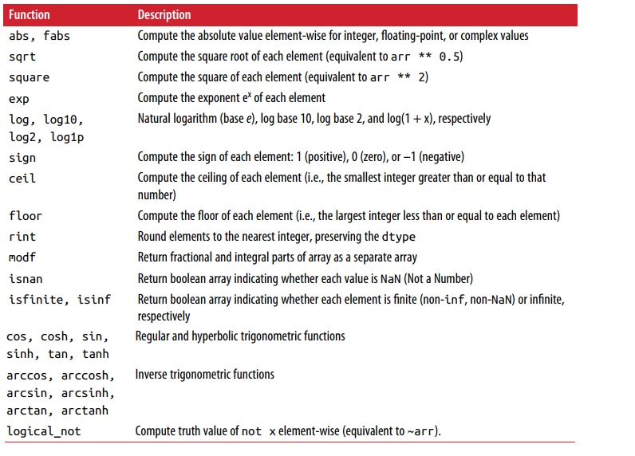

# List of binary funcs:

```
take two arrays input
```

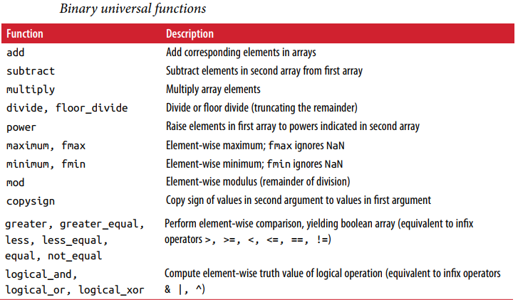

# Linear Algebra

> Like matrix multiplication, decompositions, determinants, and other square matrix math, is an important part of any array library. Unlike some languages like MATLAB, multiplying two two-dimensional arrays with * sign is an element-wise product instead of a matrix dot product. Thus, there is a function dot, both an array method and a function in the numpy namespace, for matrix multiplication. > Linear ALgebra mai matrix opoeratins perform hote hain

```python
# ye hamare pass x or y 2 matrix hain

x = np.array([[1.,2.,3.], [4.,5.,6.]])
y = np.array([[6.,23.], [-1,7], [8,9]])

print(x)
print("============")
print(y)
```

```
[[1. 2. 3.]
 [4. 5. 6.]]
============
[[ 6. 23.]
 [-1.  7.]
 [ 8.  9.]]
```

# Note:

```
* to multiply two matrices (element wise multiplication or mirror multiplication) both matrix must have same shape
* matrix multiplication 2 tarah ki hoti hai:
* 1: Mirror Multiplication: element wise hoti hai
```

```python
# to shape same nhi hai to ye error derha hai

x * y
```

```
---------------------------------------------------------------------------
ValueError                                Traceback (most recent call last)
<ipython-input-41-1b211a33497a> in <module>
      1 # to shape same nhi hai to ye error derha hai
      2
----> 3 x * y

ValueError: operands could not be broadcast together with shapes (2,3) (3,2)
```

```python
# now i create matrix with same shape

z = np.arange(6).reshape(2,3)
print(z)
print(x)
```

```
[[0 1 2]
 [3 4 5]]
[[1. 2. 3.]
 [4. 5. 6.]]
```

```python
# now i can multiply
# to ye mirror multiplication horhi har element apne saamne wale element sai multiply horha hai to ye matrix multilplication..
# .. ka tareeqa nhi hota (0 x 1.), (1 x .2) and so on
x*z
```

```
array([[ 0.,  2.,  6.],
       [12., 20., 30.]])
```

In linear algebra rows of first matrix is multiplied by the columns of second matrix and this is only possible when columns of first matrix are equal to the rows of second matrix

[figure not shown]

```python
# Order of x
x.shape
```

```
(2, 3)
```

```python
# Order of y
y.shape
```

```
(3, 2)
```

```python
# Col of x == rows of y
# hence matrix multiplication can be done
```

```python
np.dot(x,y)
```

```
array([[ 28.,  64.],
       [ 67., 181.]])
```

```python
x@y
```

```
array([[ 28.,  64.],
       [ 67., 181.]])
```

```python
np.dot(y,x)  # y.y also fulfilling the rule
```

```
array([[ 98., 127., 156.],
       [ 27.,  33.,  39.],
       [ 44.,  61.,  78.]])
```

# Note:

- `It is not necessary if a.b is possible so b.a will be`
- `np.dot(a,b)`
- `a.dot(b)`
- `a@b`
- `All are same`

# numpy.linalg

has a standard set of matrix decompositions and things like inverse and determinant. These are implemented under the hood via the same industry standard linear algebra libraries used in other languages like MATLAB and R, such as BLAS, LAPACK, or possibly (depending on your NumPy build) the proprietary Intel MKL (Math Kernel Library):Numpy linear algebra ki 1 library bani wi hai, usse hum kuch functions hum import kar rhe hian

```python
from numpy.linalg import inv, qr
```

```python
X = np.array(np.random.randn(5,5)*10, dtype="int32")
X
```

```
array([[  0,   5,  -2,  -3,   2],
       [ -5,   1,   0,   5,   4],
       [ -5,   5,   1, -11,   9],
       [  7,   1,  -8,  -9, -12],
       [ 11,   6,   2, -11,  10]])
```

```python
# inverse nikalunga array ka
inv(X)
```

```
array([[-0.03252818,  0.03220612, -0.05861514,  0.01771337,  0.06763285],
       [ 0.44669887, -0.29871176, -0.06634461, -0.13929147, -0.07729469],
       [ 0.30056361, -0.51912238, -0.02769726, -0.22926731, -0.102657  ],
       [ 0.05958132,  0.04991948, -0.07085346, -0.02254428,  0.00483092],
       [-0.22681159,  0.30253623,  0.03188406,  0.08514493,  0.09782609]])
```

The expression X.T.dot(X) computes the dot product of X with its transpose X.T

```python
# X ka transpose lo, uska dot product nikaaldo apne hee X ke sath
mat = X.T.dot(X)
mat
```

```
array([[ 220,   43,  -39, -154,  -39],
       [  43,   88,   -1, -140,  107],
       [ -39,   -1,   73,   45,  121],
       [-154, -140,   45,  357,  -87],
       [ -39,  107,  121,  -87,  345]])
```

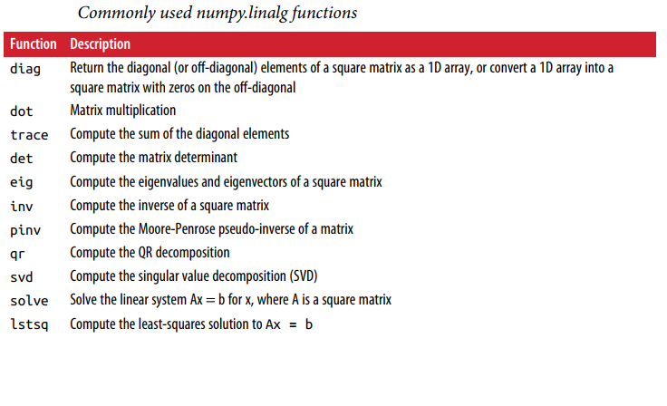

```python
# Question: How can we get element form 3d array?
# Now i want to access element 38

arr3d = np.arange(64).reshape(4,4,4)
arr3d
```

```
array([[[ 0,  1,  2,  3],
        [ 4,  5,  6,  7],
        [ 8,  9, 10, 11],
        [12, 13, 14, 15]],

       [[16, 17, 18, 19],
        [20, 21, 22, 23],
        [24, 25, 26, 27],
        [28, 29, 30, 31]],

       [[32, 33, 34, 35],
        [36, 37, 38, 39],
        [40, 41, 42, 43],
        [44, 45, 46, 47]],

       [[48, 49, 50, 51],
        [52, 53, 54, 55],
        [56, 57, 58, 59],
        [60, 61, 62, 63]]])
```

```python
# arr3d[depth,row,col]

arr3d[2,1,2]
```

```
38
```

# -------------------------------`Syllabus Completed`------------------------------------

# Additional And Informational:

# Importing Image Data into NumPy Arrays

In machine learning, Python uses image data in the from of a NumPy array, i.e, [Height, Width, Channel] format. To enhance the performance of the predictive model, we must know how to load and manipulate images. In Python, we can perfrom one task in different ways. We have options from NumPy to Pytorch and CUDA, depending on the complexity of the problem.

By the end of this example, you will have hands-on experience with:

[output not shown]

# Pillow Library

Pillow is preferred image manipulation tool. Python version 2 used Python Image Library(PIL), and Python version 3 uses Pillow Python Library, an upgrade of PIL.

You should first create a virtual environment in Anaconda for different projects. Make sure you have supporting packages like NumPy, SciPy, and Matplotlib to install in the virtual environment you create.

Once you set up the packages, you can easily install Pillow using pip.

###### #

> pip install Pillow

###### #

> pip install Pillow --upgrade

Image ko NumPy array mai convert karne keliye main Python ki libraray Pillow use karunga, ye kaam mai Pillow sai bhi karsakta hun, matplotlib sai bhi karsakta hun, Keras joke TensorFlow ki API hai us sai bhi karsataka hun, OpenCV use karsata hun

```python
import PIL
print("Pillow Version:", PIL.__version__)
```

```
Pillow Version: 8.0.1
```

```python
# Load and show an image with Pillow
# Image ki class import karli

from PIL import Image
```

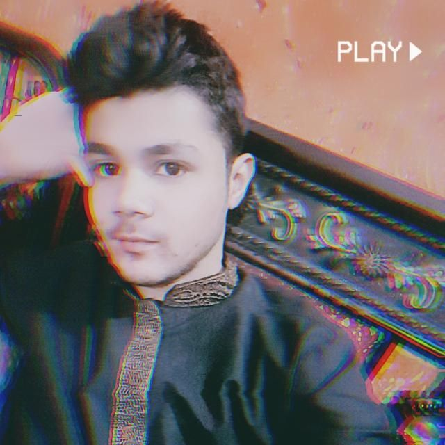

```python
# Open the image from working directory
image = Image.open('shahid.jpg')

image
```

```python
# summarize some details about the image, row and col hain pixels ki shakal main to 640 rows and 640 cols hain
# ye 2 dimensional image hai
print(image.format)
print(image.size)
print(image.mode)
```

[output not shown]

```python
# Pillow ka eik object hai
type(image)
```

[output not shown]

```
PIL.JpegImagePlugin.JpegImageFile
```

# Converting image into NumPy array

```python
# asarray() ka function data type change karne keliye use karte hain

imgarray = np.asarray(image)
```

```python
# ab meri image array bangyi
type(imgarray)
```

```
numpy.ndarray
```

```python
# 3d hai qk color image hai
# width, height, channels(RGB)
imgarray.shape
```

```
(640, 640, 3)
```

```python
# vector banadiya
# 3eeno factors multiply hogye, or 1228800 pixels is image ke mojood hain
imgarray.ravel().shape
```

```
(1228800,)
```

```python
print(640 * 640 * 3)
```

```
1228800
```

# Load and display an image with matplotlib

Ab mai yehi kaam matplotlib ki library sai karunga

```python
# Load and display an image with matplotlib
# maine image ki class uthali or plot karne ka pyplot uthaliya
from matplotlib import image
from matplotlib import pyplot
```

```python
# load image as pixel array
# ab qk ye matplotlib ki library hai to usne automatically numpy array mai convert kardi image
# 3d image hai yaani 3 channels hain iske
img = image.imread('shahid.jpg')
img
```

```
array([[[188, 136, 112],
        [188, 136, 112],
        [188, 136, 112],
        ...,
        [197, 148, 131],
        [197, 148, 131],
        [197, 148, 131]],

       [[188, 136, 112],
        [188, 136, 112],
        [188, 136, 112],
        ...,
        [197, 148, 131],
        [197, 148, 131],
        [197, 148, 131]],

       [[189, 137, 113],
        [189, 137, 113],
        [189, 138, 111],
        ...,
        [197, 148, 131],
        [197, 148, 131],
        [197, 148, 131]],

       ...,

       [[ 21,  38,  56],
        [ 20,  37,  53],
        [ 20,  36,  51],
        ...,
        [ 34,  36, 173],
        [ 44,  53, 184],
        [ 59,  72, 200]],

       [[ 21,  38,  54],
        [ 20,  37,  53],
        [ 20,  36,  51],
        ...,
        [ 34,  39, 169],
        [ 43,  55, 177],
        [ 59,  76, 194]],

       [[ 21,  38,  54],
        [ 20,  38,  52],
        [ 20,  36,  51],
        ...,
        [ 33,  38, 164],
        [ 40,  55, 174],
        [ 55,  75, 188]]], dtype=uint8)
```

```python
# summarize shape of the pixel array
print(img.dtype)
print(img.shape)
```

```
uint8
(640, 640, 3)
```

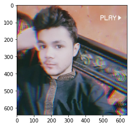

```python
# display the array of pixels as an image
# array of pixels ko image main kese convert karenge, to pehle imread ka function tha jo read karta hai image ko array mai
# ab mai yahan imshow() ka function ko use kar rha hun jo dobarah array ko img mai convert kardega
pyplot.imshow(img)
pyplot.show()
```

# Manipulating and saving the image

After performing the manipulations, it is important to save the image before performing further steps. The format argument saves the file in different formats such as PNG, GIF, or JPEG.

For example, the code below loads the photograph in JPEG format and saves it in PNG format

to kia mai 2 images ko apas mai jor sakta hun ? concatenate karlenege

```python
import numpy as np
from PIL import Image

myImg = Image.open('shahid.jpg')
myImg = myImg.convert('L')        # L isko grayscale mai convert kardega
myImg = np.array(myImg)
# myImg = np.array(Image.open('abc.jpg').convert())  # uppar 3 lines waal kaam 1 line mai bhi hosakta hai

print(type(myImg))

gr_img = Image.fromarray(myImg).save('gr_shahid.png')

print(gr_img)
```

```
<class 'numpy.ndarray'>
None
```